# HW 8 - MCMC

Sophie Shan

3/27/2024

# Importance and Rejection Sampling

Consider finding $\sigma^2 = E[X^2]$ when $X$ has the density that is proportional to $q(x) =\exp({−|x|^3/3})$. Write the form of the integral pertaining to this expectation below, assuming the normalizing constant for $q(x)$ is $c$.

Solution:

$$\sigma^2 = E[X^2] = \int_{0}^{\infty}
x^2 c \exp(-\frac{|x|^3}{3}) \, dx$$

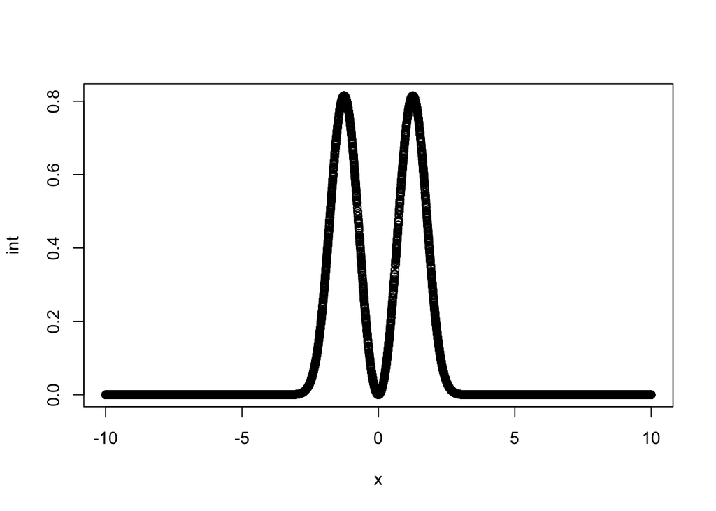

```r
#library
library(MASS)

#plot function under integral
x <- runif(10000, min = -10, max = 10)
int <- x^2 * exp( - abs(x)^3/3)

plot(x, int)
```

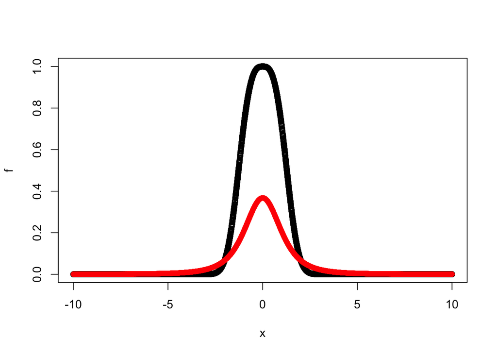

```r
#plot function f(x)

f <- exp( - abs(x)^3/3)
g <- dt(x, df = 3)
plot(x, f)
points(x, g, col='red', pch=16)
```

## Find the estimate for $\sigma^2$ using importance sampling.

Write the expression for the integral using an importance sampling scheme, specifying your choice for the importance sampling density $g$ and reexpress the integral in terms of $X^2$, $g(x)$ and $q(x)$. Then, write the form of the approximation of this integrand based on the importance samples drawn from $g$. Then, carry out this approximation of the expectation in the code below.

$$\int_{0}^{\infty} x^2 c
\exp(-\frac{|x|^3}{3}) \, dx \propto \int_{0}^{\infty} x^2
\frac{\exp(-\frac{|x|^3}{3}) }{(1 + \frac{x^2}{3})^2} (1 +
\frac{x^2}{3})^2 \, dx$$

```r
## Solution: write any helper functions here (q(x), etc)
q <- function(x) {exp( - abs(x)^3/3)}

#we choose t-distribution to be importance sampling function
g <- function(x) {dt(x, df = 3)}

## End Solution

# set M
M = 10^5

## Solution: place primary code evaluating the expectation here with importance sampling

#draw from importance sampling function
y_imp <- rt(M, df = 3)

#compute importance weights
w_star <- q(y_imp) / g(y_imp)

#compute MC estimate of integral
mean(y_imp^2 * w_star)
```

```
## [1] 1.995108
```

## Repeat the procedure using rejection sampling.

Similar to before, write out the form of the integral and then its approximation, this time based on sampling from the target density $q(x)$. Then, carry out this approximation of the expectation in the code below.

$$\int_{0}^{\infty} x^2 c
\exp(-\frac{|x|^3}{3}) \, dx = \frac{1}{M} \sum_{i=1}^{M} x_i^2$$
Note: These $x_i$ are the samples that are accepted through the rejection sampling process.

We use the same g(x) as above (t-distribution with 3 degrees of freedom), but we scale it by an alpha of 1/4 as the envelope function.

Repeat until we reach desired sample size.

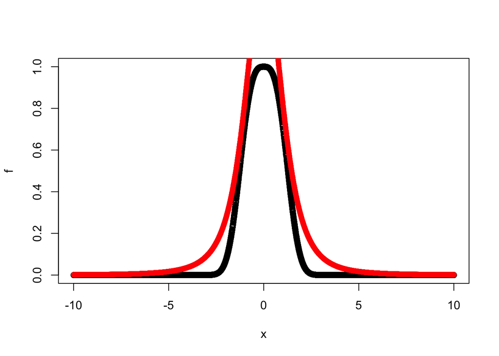

```r
#finding the envelope function

#plot function f(x)
f <- exp( - abs(x)^3/3)
g <- dt(x, df = 3)

plot(x, f)
points(x, g*4, col='red', pch=16)
```

Hint: We just need to show that $e$ exceeds the target density everywhere, and that the distribution $g$ that we draw samples from only differs from $e$ by a constant $\alpha$.

```r
#functions
q <- function(x) {exp( - abs(x)^3/3)}

#we choose t-distribution to be importance sampling function
g <- function(x) {dt(x, df = 3)}

#set alpha
alpha <- 1/4

# set M
M = 10^5

#specify max number of iterations
maxit = 100000

## Solution: place primary code evaluating the expectation here with rejection sampling

#Store accepted samples
samples_accepted <- rep(0, M)

# start rejection algorithm
i = index = 1

while (i <= M & index < maxit) {

  # sample x from g(x)
  x_proposed <- rt(1, df = 3)

  # sample Ui from standard uniform
  Ui = runif(1)

  # calculate ratio
  Lq = q(x_proposed)
  Le = g(x_proposed)/alpha
  r = Lq / Le

  # if Step 3 condition met, save sample
  if (Ui < r) {
    samples_accepted[i] = x_proposed
    # update iterator
    i = i + 1
  }

  # keep track of total number of samples drawn
  index = index + 1
}

# Compute the estimate of E[X^2]
mean(samples_accepted^2)
```

```
## [1] 0.4997333
```

```r
## End Solution
```